# Grades of Students by School

```r
grades <- read.csv('data.csv')
```

```r
cols <- c("school", "section", "very_ahead", "middling", "behind", "more_behind", "very_behind", "completed")
colnames(grades) <- cols
```

```r
attach(grades)
```

```r
summary(grades)
```

```
 school    section        very_ahead    middling         behind
 A:13   Min.   : 1.00   Min.   :0    Min.   : 2.00   Min.   : 4.00
 B:12   1st Qu.: 2.25   1st Qu.:0    1st Qu.: 4.25   1st Qu.:15.25
 C: 3   Median : 5.50   Median :0    Median : 7.50   Median :22.00
 D: 1   Mean   : 5.90   Mean   :0    Mean   : 7.40   Mean   :25.13
 E: 1   3rd Qu.: 9.00   3rd Qu.:0    3rd Qu.: 9.75   3rd Qu.:34.25
        Max.   :13.00   Max.   :0    Max.   :19.00   Max.   :56.00
  more_behind      very_behind       completed
 Min.   : 0.000   Min.   : 0.000   Min.   : 1.00
 1st Qu.: 1.000   1st Qu.: 1.250   1st Qu.: 6.00
 Median : 2.000   Median : 5.500   Median :10.00
 Mean   : 3.333   Mean   : 6.967   Mean   :10.53
 3rd Qu.: 4.750   3rd Qu.:11.500   3rd Qu.:14.00
 Max.   :12.000   Max.   :24.000   Max.   :27.00
```

```r
sections_by_school <- aggregate(section, by = list(school), FUN = max)
sections_by_school
```

| Group.1 | x |
| --- | --- |
| A | 13 |
| B | 12 |
| C | 3 |
| D | 1 |
| E | 1 |

```r
current_course <- max(grades[which(school == "B"), ]$section) / 3 * 4
30 - current_course
```

```
[1] 14
```

If one of the schools which has the most sections completed, school B, only has 12 sections done. And the semester is already 3/4 of the way through. They will have to do 14 more sections (2 more than they’ve completed to date) in 1/3 of the time – 1/4 of the total time of the semester.

This seems odd. Either the final sections of this math course are increasingly easier than the previous 3/4, or they will have to rush the last 1/4 of the semester, or they may not finish. Unless the first 3/4 of the semester are filled with days off for holidays and the previous pace was comparatively slow. Which still would not explain why C, D, and E only have one to three sections done.

(School B was chosen because 12 cleanly makes 3/4 of 16.)

```r
maxA <- max(grades[which(school == "A"), ]$section)
maxB <- max(grades[which(school == "B"), ]$section)
grades[which(school == "A" & section == maxA), "completed"]
```

```
[1] 5
```

Five kids have finished from school A.

```r
grades[which(school == "B" & section == maxB), "completed"]
```

```
[1] 19
```

19 kids have finished from school B.

```r
max(very_ahead)
```

```
[1] 0
```

No kids in any school are ‘very ahead’.

```r
# Some quick histograms
getHist <- function(vectorX, bin, xlabel = "x", ylabel = "y") {
  qplot(vectorX,
        geom="histogram",
        binwidth = bin,
        fill=I("steelblue"),
        col=I("darkorange"),
        xlab = xlabel,
        ylab = ylabel
        )
}
```

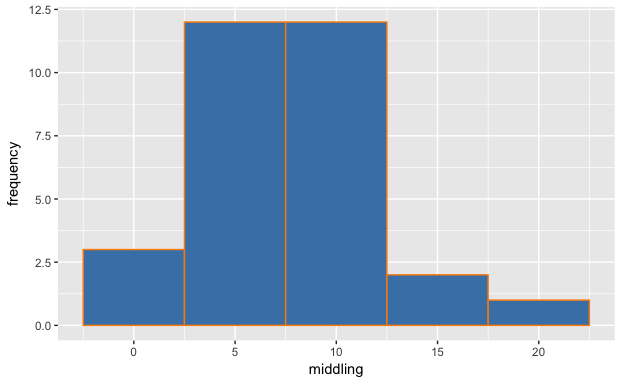

```r
getHist(middling, 5, "middling", "frequency")
```

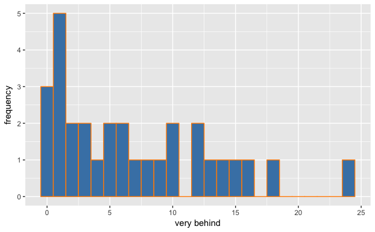

```r
getHist(very_behind, 1, "very behind", "frequency")
```

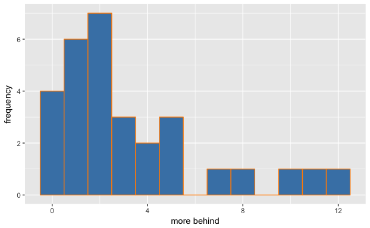

```r
getHist(more_behind, 1, "more behind", "frequency")
```

Not much can be derived from these, there aren’t strong patterns here. One stand-out is that one section of one school reported over 20 kids (almost 25) were ‘very behind.’

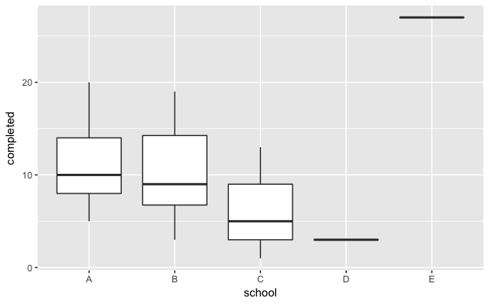

```r
ggplot(grades, aes(x = school, y = completed)) + geom_boxplot()
```

This is a strange result. If we remember from earlier, School E only has one section finished and they have over 20 kids who have completed the entire course.

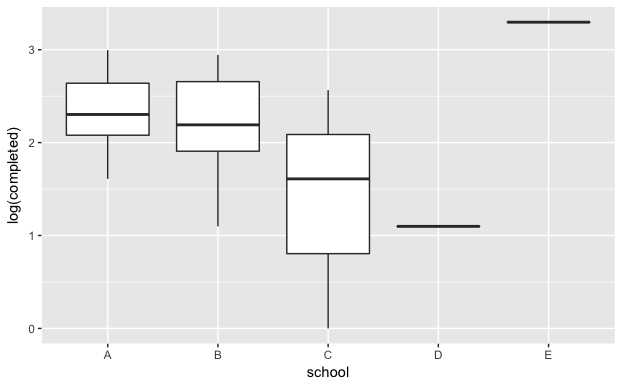

```r
ggplot(grades, aes(x = school, y = log(completed))) + geom_boxplot()
```

Changing the completed to log evens out the schools that have finished fewer sections, but shows school E is still an outlier.

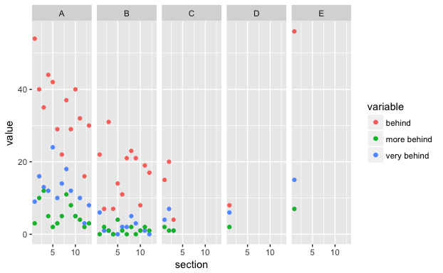

```r
behind_plot <- ggplot(grades, aes(x = section, y = value, color = variable)) +
  geom_point(aes(y = very_behind, col = "very behind")) +
  geom_point(aes(y = more_behind, col = "more behind")) +
  geom_point(aes(y = behind, col = "behind")) +
  facet_grid(. ~ school)
behind_plot
```

This shows a gradual downtrend among students who are behind each week as the sections progress.

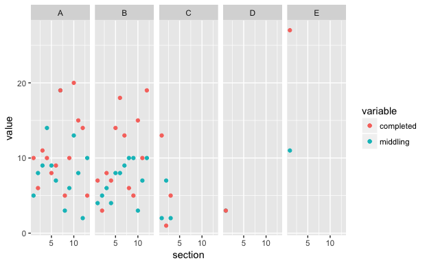

```r
doing_well_plot <- ggplot(grades, aes(x = section, y = value, color = variable)) +
  geom_point(aes(y = middling, col = "middling")) +
  geom_point(aes(y = completed, col = "completed")) +
  facet_grid(. ~ school)
doing_well_plot
```

Here there is random noise, but a noticeable uptrend among middling students each section as school B.